# malacoda simulations

Andrew Ghazi

# 1 Goal

This document describes the simulations used to statistical gains from using the malacoda method of MPRA analysis under ideal situations, while varying important parameters. Simulation is a key tool in computational studies because it permits the evaluation of methods under controlled statistical settings. For this study our objective is to examine the performance of malacoda compared to the alternative MPRA analysis methods. To construct the simulations requires the identification of the key parameters in the MPRA problem. These parameters are:

- assay size (number of variants)
- barcodes per allele
- dispersion
- effect size distribution (and fraction of truly functional variants)
- and for the use of conditional priors, the strength of the association between transcription shift and a single functional predictor.

# 2 Core simulation functions

Simulation assumptions used in this study which are consistent with real experimental MPRA studies:

- there are 3 DNA sequencing samples
- 6 RNA sequencing samples
- 200 million reads in the NGS assay in total

Using the assumptions above to generate an example MPRA dataset with 3000 variants and 14 barcodes per allele, with 15% failed barcodes, there are on average 200M / 9 * 0.85 / 3000 / (14*2) = 224 reads of a single barcode in a single sample.

This function simulates the sequencing depth of an assay across samples. The `rdirichlet` alpha parameters are chosen by inspection. It assumes that the 9 multiplexed samples are evenly sequenced on average, and that the per-sample depths typically range from about 15M to 30M:

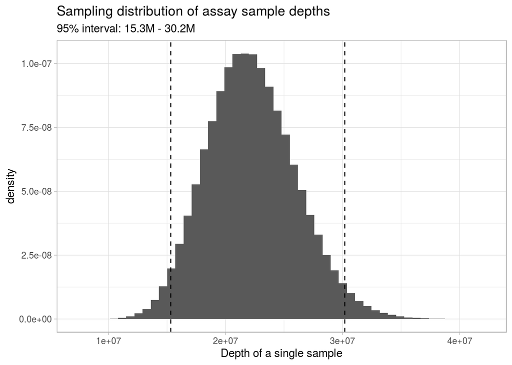

```r
library(tidyverse)
library(magrittr)
simulate_depth_factors = function(depth_multiplier = 1e6,
                                  tot_reads = 200e6,
                                  n_dna = 3,
                                  n_rna = 6,
                                  conc_par = 30){
  tibble(sample_id = c(paste0('DNA_', 1:n_dna),
                       paste0('RNA_', 1:n_rna)),
         depth_factor = as.vector(floor(gtools::rdirichlet(1, alpha = rep(conc_par, n_dna + n_rna)) * tot_reads) /
           depth_multiplier))
}

depth_sim = {200e6*gtools::rdirichlet(50000, alpha = rep(30, 9))} %>%
  set_colnames(1:9) %>%
  as_tibble %>%
  gather(sample_id, depth)

depth_sim %>%
  ggplot(aes(depth)) +
  geom_histogram(aes(y = ..density..), bins = 50) +
  geom_vline(lty = 2,
             xintercept = quantile(depth_sim$depth, prob = c(.025, .975))) +
  theme_light() +
  labs(title = 'Sampling distribution of assay sample depths',
       subtitle = '95% interval: 15.3M - 30.2M',
       x = 'Depth of a single sample')
```

The $\alpha$ and $\beta$ parameters were chosen from inspection based on the marginal prior from our primary MPRA dataset.

`simulate_variant()` simulates a single variant. `simulate_assay()` assigns random effect sizes and calls `simulate_variant()` a set number of times. The effect sizes $ES$ in `simulate_assay()` are set to 0 at a defined fraction (1 - `p_func`), and the remainder drawn from +/- 1 times a random draw from $Gamma(\alpha = 2, \beta = 2)$ distribution.

```r
initial_depths = simulate_depth_factors()

simulate_draws = function(n, means, disp){
  map_dbl(means, ~rnbinom(n = n,
                          mean = .x,
                          size = disp))
}

simulate_variant = function(variant_id ,
                            effect_size, # input using log-scale, it get's exp()'d inside
                            depth_factors, # depth factors of the samples
                            n_barcodes = 14,
                            dna_mu = rgamma(n_barcodes * 2, shape = 3.42, rate = .203),
                            dna_phi = rgamma(1, shape = 18.4, rate = 16.7),
                            rna_mu = rgamma(1, shape = 3, rate = 3),
                            ref_rna_phi = rgamma(1, shape = 7.43, rate = 8.99),
                            alt_rna_phi = rgamma(1, shape = 7.62, rate = 9.41),
                            fail_rate = 0.15,
                            fail_reduction = 50){

  ref_rna_mu = rna_mu
  alt_rna_mu = exp(effect_size) * rna_mu

  out_df = tibble(allele = c(rep('ref', n_barcodes),
                             rep('alt', n_barcodes)),
                  bc_id = 1:(2*n_barcodes),
                  dna_means = dna_mu,
                  dna_size = dna_phi,
                  rna_mean = rep(c(ref_rna_mu, alt_rna_mu), each = n_barcodes),
                  rna_phi = rep(c(ref_rna_phi, alt_rna_phi), each = n_barcodes),
                  failed = runif(2*n_barcodes) < fail_rate)

  out_df$dna_means[out_df$failed] = 1/fail_reduction * out_df$dna_means[out_df$failed]

  mean_by_cell = outer(Y = depth_factors %>%
                           filter(grepl('DNA', sample_id)) %>%
                           pull(depth_factor),
                       X = out_df$dna_means) %>%
    set_colnames( depth_factors %>%
                    filter(grepl('DNA', sample_id)) %>% pull(sample_id)) %>%
    as_tibble %>%
    mutate(bc_id = 1:(2*n_barcodes)) %>%
    gather(sample_id, depth_mean, -bc_id)

  dna_draws = mean_by_cell %>% mutate(draws = map_dbl(depth_mean, ~rnbinom(n = 1, mu = .x,
                                                                           size = dna_phi))) %>%
    dplyr::select(-depth_mean) %>%
    spread(sample_id, draws)

  rna_adjusts = tibble(bc_id = 1:(2*n_barcodes),
                       rna_adj = rep(c(ref_rna_mu, alt_rna_mu),
                                     each = n_barcodes))

  disp_by_id = tibble(bc_id = 1:(2*n_barcodes),
                      disp = c(rep(ref_rna_phi, n_barcodes),
                               rep(alt_rna_phi, n_barcodes)))

  rna_mean_by_cell = outer(Y = depth_factors %>%
                           filter(grepl('RNA', sample_id)) %>%
                           pull(depth_factor),
                           X = out_df$dna_means) %>%
    set_colnames( depth_factors %>%
                    filter(grepl('RNA', sample_id)) %>% pull(sample_id)) %>%
    as_tibble %>%
    mutate(bc_id = 1:(2*n_barcodes)) %>%
    gather(sample_id, depth_mean, -bc_id)

  rna_draws = rna_mean_by_cell %>%
    left_join(rna_adjusts, by = 'bc_id') %>%
    mutate(rna_depth_mean = depth_mean * rna_adj) %>%
    dplyr::select(-depth_mean, -rna_adj) %>%
    left_join(disp_by_id, by = 'bc_id') %>%
    mutate(draws = map2_dbl(rna_depth_mean,
                            disp,
                           ~rnbinom(1, mu = .x, size = .y))) %>%
    dplyr::select(-rna_depth_mean, -disp) %>%
    spread(sample_id, draws)

  out_df %<>%
    mutate(variant_id = variant_id) %>%
    left_join(dna_draws, by = 'bc_id') %>%
    left_join(rna_draws, by = 'bc_id')

  return(out_df)
}

simulate_assay = function(n_variants = 5000,# number of variants in the MPRA
                          p_func = .05, # probability of functionality
                          n_bpa){  # number barcodes per allele
  initial_depths = simulate_depth_factors()

  tibble(variant_id = map_chr(1:n_variants, ~paste0(sample(letters, size = 8), collapse = '')),
         truly_functional = runif(n_variants) < p_func,
         effect_size = truly_functional *
           sample(c(-1,1), size = n_variants, replace = TRUE) *
           rgamma(n_variants, shape = 2, rate = 2),
         variant_data = map2(variant_id, effect_size,
                             simulate_variant,
                             depth_factors = initial_depths,
                             n_barcodes = n_bpa))
}
```

The next two tables show one example call to `simulate_depth_factors` followed by one call to `simulate_variant()` with effect size -1 and 5 barcodes per allele.

```r
set.seed(1234)
knitr::kable(initial_depths)
```

| sample_id | depth_factor |
| --- | --- |
| DNA_1 | 30.63747 |
| DNA_2 | 16.34419 |
| DNA_3 | 24.22605 |
| RNA_1 | 18.80402 |
| RNA_2 | 18.72371 |
| RNA_3 | 21.80860 |
| RNA_4 | 24.95988 |
| RNA_5 | 20.15548 |
| RNA_6 | 24.34059 |

```r
simulate_variant(variant_id = 'test_variant',
                 effect_size = -1,
                 depth_factors = initial_depths, n_barcodes = 5) %>%
  select(-variant_id, -bc_id) %>%
  knitr::kable(digits = 3, format =  'html') %>%
  kableExtra::kable_styling(full_width = TRUE, font_size = 10)
```

| allele | dna_means | dna_size | rna_mean | rna_phi | failed | DNA_1 | DNA_2 | DNA_3 | RNA_1 | RNA_2 | RNA_3 | RNA_4 | RNA_5 | RNA_6 |
| --- | --- | --- | --- | --- | --- | --- | --- | --- | --- | --- | --- | --- | --- | --- |
| ref | 17.152 | 1.329 | 0.319 | 0.739 | FALSE | 328 | 45 | 86 | 80 | 13 | 218 | 160 | 238 | 129 |
| ref | 17.568 | 1.329 | 0.319 | 0.739 | FALSE | 643 | 377 | 156 | 315 | 3 | 16 | 109 | 3 | 263 |
| ref | 8.892 | 1.329 | 0.319 | 0.739 | FALSE | 36 | 87 | 82 | 79 | 75 | 16 | 67 | 433 | 7 |
| ref | 18.959 | 1.329 | 0.319 | 0.739 | FALSE | 989 | 94 | 150 | 17 | 85 | 279 | 157 | 6 | 8 |
| ref | 9.953 | 1.329 | 0.319 | 0.739 | FALSE | 585 | 95 | 588 | 6 | 25 | 221 | 308 | 11 | 26 |
| alt | 23.853 | 1.329 | 0.117 | 0.762 | FALSE | 1429 | 237 | 224 | 10 | 64 | 79 | 10 | 1 | 20 |
| alt | 9.622 | 1.329 | 0.117 | 0.762 | FALSE | 519 | 138 | 416 | 12 | 29 | 20 | 58 | 94 | 41 |
| alt | 10.648 | 1.329 | 0.117 | 0.762 | FALSE | 37 | 124 | 295 | 18 | 24 | 39 | 2 | 7 | 24 |
| alt | 3.422 | 1.329 | 0.117 | 0.762 | FALSE | 36 | 23 | 61 | 3 | 2 | 12 | 14 | 11 | 2 |
| alt | 14.932 | 1.329 | 0.117 | 0.762 | FALSE | 323 | 178 | 400 | 15 | 6 | 22 | 129 | 92 | 64 |

# 3 Define Simulation grid

The code block below defines a parameter grid, altering the following values:

```r
sim_grid = expand.grid(list(p_func = c(.0, .05, .1),
                            n_variants = c(300, 1000, 3000),
                            n_bpa = c(10, 30))) %>%
  as_tibble %>%
  mutate(point_ids = map2(p_func, n_variants, ~tibble(sim_id = map_chr(1:100, ~paste0(sample(letters, size = 8), collapse = ''))))) %>%
  unnest

save(sim_grid,
     file = '/mnt/bigData2/andrew/MPRA/sim_mpra/many_sims/sim_grid.RData')

sim_once_save = function(sim_id, p_func, n_variants, n_bpa){
  current_sim = simulate_assay(p_func = p_func, n_variants = n_variants, n_bpa = n_bpa)

  save(current_sim,
       file = paste0('/mnt/bigData2/andrew/MPRA/sim_mpra/many_sims/', sim_id, '.RData'))

  return('donesk')
}

sim_grid %>%
  mutate(make_sims = parallel::mcmapply(sim_once_save,
                                        sim_id, p_func, n_variants, n_bpa,
                                        mc.preschedule = FALSE,
                                        mc.cores = 16))

print('SUPER DONESK')
```

# 4 Evaluate methods on simulated data

Each subsection below runs a given MPRA analysis method on the simulated assays (or a substantial subset of them for malacoda and MPRAnalyze, the two slowest methods) and assesses their performance according to the four metrics outlined in the “Compare all methods” section below.

## 4.1 Run malacoda on simulations

The code block below fits the malacoda model (marginal prior) on a random subset of the simulation grid using a marginal prior and 10000 posterior samples. The outputs for a single large simulation are on the order of 10 GB, so we instead only analyze 26 simulated assays from each simulation grid point.

```r
library(tidyverse)
library(magrittr)
library(malacoda)

load('/mnt/bigData2/andrew/MPRA/sim_mpra/many_sims/sim_grid.RData')

malacoda_sim = function(sim_id){
  # make the output directory
  sim_out_dir = paste0('/mnt/bigData2/andrew/MPRA/sim_mpra/many_sims_malacoda/', sim_id)
  dir.create(sim_out_dir)

  # load the simulated assay
  load(paste0('/mnt/bigData2/andrew/MPRA/sim_mpra/many_sims/', sim_id, '.RData'))

  # malacoda needs a barcode column, so add one
  fake_bcs = sample(x = c('A', 'C', 'G', 'T'),
                    size = nrow(unnest_legacy(current_sim))*16,
                    replace = TRUE) %>%
    matrix(nrow = nrow(unnest_legacy(current_sim))) %>%
    apply(MARGIN = 1, FUN = paste0, collapse = '')

  if (n_distinct(fake_bcs) < nrow(current_sim)){
    while (n_distinct(fake_bcs) < nrow(current_sim)) {
      fake_bcs = sample(x = c('A', 'C', 'G', 'T'),
                        size = nrow(current_sim)*16,
                        replace = TRUE) %>%
        matrix(nrow = nrow(current_sim)) %>%
        apply(MARGIN = 1, FUN = paste0, collapse = '')
    }
  }

  # Format simulated mpra data
  md = current_sim %>%
    unnest_legacy %>%
    mutate(barcode = fake_bcs) %>%
    select(variant_id, allele, barcode, matches('[DR]NA', ignore.case = FALSE))

  sim_sd = get_sample_depths(md)

  wr = get_well_represented(md,
                            sample_depths = sim_sd,
                            rep_cutoff = .15,
                            plot_rep_cutoff = FALSE,
                            verbose = FALSE)

  # fit the marginal prior
  sim_prior = fit_marg_prior(md,
                             n_cores = 16,
                             rep_cutoff = .15,
                             plot_rep_cutoff = FALSE)

  # fit the model
  model_fit = fit_mpra_model(md,
                             n_cores = 16,
                             save_nonfunctional = TRUE,
                             tot_samp = 10000,
                             n_warmup = 500,
                             vb_pass = FALSE,
                             verbose = FALSE,
                             rep_cutoff = .15,
                             out_dir = sim_out_dir,
                             priors = sim_prior)


  return('done :)')
}

sim_grid %>%
  group_by(p_func, n_variants, n_bpa) %>%
  do(head(., 26)) %>%
  mutate(group_index = 1:n()) %>% # Hoping to make the timing uniform
  ungroup %>%
  arrange(group_index) %>%
  mutate(malacoda_fit = parallel::mclapply(sim_id,
                                           malacoda_sim,
                                           mc.cores = 10,
                                           mc.preschedule = FALSE))
```

The code block below evaluates malacoda’s performance on each simulated assay.

```r
library(tidyverse)
library(magrittr)
library(malacoda)
library(pROC)

load('/mnt/bigData2/andrew/MPRA/sim_mpra/many_sims/sim_grid.RData')

variant_cutoff = function(sim_id, variant_id){
  # for a given variant, this function returns the TS HDI threshold necessary to call it functional

  load(paste0('/mnt/bigData2/andrew/MPRA/sim_mpra/many_sims_malacoda/', sim_id, '/', variant_id, '.RData'))

  ts_samples = sampler_res %>% rstan::extract(pars = 'transcription_shift') %>% .$transcription_shift

  above_zero = rstan::summary(sampler_res)$summary['transcription_shift', 'mean'] > 0

  # If the variant has a negative posterior shift, you need to see how wide the
  # HDI needs to be to make the region ABOVE zero plausible. Otherwise it's vice
  # versa.
  if(above_zero){
    frac_opposite = sum(ts_samples < 0) / length(ts_samples)
  } else {
    frac_opposite = sum(ts_samples > 0) / length(ts_samples)
  }

  if (frac_opposite > .5) {
    frac_opposite = 1 - frac_opposite
  }

  necessary_cutoff = 1 - 2*frac_opposite # The width of the HDI necessary to include 0

  return(necessary_cutoff)
}

malacoda_performance = function(sim_id){

  load(paste0('/mnt/bigData2/andrew/MPRA/sim_mpra/many_sims_malacoda/', sim_id, '/analysis_res.RData'))
  load(paste0('/mnt/bigData2/andrew/MPRA/sim_mpra/many_sims/', sim_id, '.RData'))


  file_check = file.exists(paste0('/mnt/bigData2/andrew/MPRA/sim_mpra/many_sims_malacoda/', sim_id, '/joined_df.RData'))

  if (file_check){
    load(paste0('/mnt/bigData2/andrew/MPRA/sim_mpra/many_sims_malacoda/', sim_id, '/joined_df.RData'))

    typical_table =  joined_df %>%
      select(truly_functional, is_functional) %>%
      table
  } else{
    joined_df = analysis_res %>%
      select(-`variant_data`) %>%
      left_join(current_sim,
                by = 'variant_id')

    typical_table =  joined_df %>%
      select(truly_functional, is_functional) %>%
      table

    joined_df %<>% # this is slow, save the result just in case
      mutate(hdi_cutoff = map_dbl(variant_id,
                                  variant_cutoff,
                                  sim_id = sim_id))

    save(joined_df,
         file = paste0('/mnt/bigData2/andrew/MPRA/sim_mpra/many_sims_malacoda/', sim_id, '/joined_df.RData'))

  }

  if (!any(joined_df$truly_functional)){
    auc_val = NA
    aupr = NA
  } else {
    roc_obj = pROC::roc(response = joined_df$truly_functional,
                        predictor = joined_df$hdi_cutoff)
    auc_val = pROC::auc(roc_obj);

    approx_df = joined_df %>%
      mutate(all_over = hdi_cutoff == 1 | hdi_cutoff == 0)

    approx_lm = approx_df %>%
      filter(!all_over) %>%
      lm(atanh(hdi_cutoff) ~ abs(ts_post_mean),
         data = .) %>%
      summary

    approx_coef = approx_lm$coefficients

    # approx_df %>%
    #   ggplot(aes(abs(ts_post_mean), hdi_cutoff)) +
    #   geom_point(aes(color = all_over)) +
    #   scale_y_continuous(trans = 'atanh') +
    #   geom_smooth(method = 'lm')

    # ^ tanh(-.13 + 7.05*abs(ts_post_mean)) is a pretty good approximation of the 1- "p-value"

    approx_df %<>%
      mutate(approx_cutoff = case_when(!all_over ~ hdi_cutoff,
                                       TRUE ~ tanh(approx_coef[2,'Estimate']*abs(ts_post_mean) - approx_coef[1,'Estimate'])))

    approx_roc_obj = pROC::roc(predictor = 1-approx_df$approx_cutoff,
                               response = approx_df$truly_functional)

    approx_coords = pROC::coords(approx_roc_obj,
                           ret = c('recall', 'precision'),
                           transpose = FALSE)

    # Compute AUPR using the trapezoidal rule
    pr_mat = approx_coords %>%  .[nrow(.):1,] %>% .[!duplicated(.$recall),]
    nrow_pr = nrow(pr_mat)
    drecall = pr_mat[2:nrow_pr,1] - pr_mat[1:(nrow_pr - 1),1]
    avg_precision = (pr_mat[2:nrow_pr, 2] + pr_mat[1:(nrow_pr - 1), 2]) / 2
    avg_precision[1] = pr_mat[2,2] # the first precision value is returned as NaN -- set to next value
    daupr = drecall * avg_precision
    aupr = sum(daupr)
  }


  spread_at_zero = joined_df %>%
    filter(!truly_functional) %>%
    pull(ts_post_mean) %>%
    sd

  nonzero_cor = joined_df %>%
    filter(truly_functional) %$%
    cor(effect_size, ts_post_mean);

  res_df = tibble(auc = auc_val,
                  aupr = aupr,
                  spread_at_zero = spread_at_zero,
                  nonzero_cor = nonzero_cor,
                  typical_table = list(typical_table))

  return(res_df)
}

malacoda_perf = list.files('/mnt/bigData2/andrew/MPRA/sim_mpra/many_sims_malacoda') %>%
  pbmcapply::pbmclapply(malacoda_performance,
                     mc.cores = 16,
                     mc.preschedule = FALSE)


malacoda_perf = tibble(sim_id = list.files('/mnt/bigData2/andrew/MPRA/sim_mpra/many_sims_malacoda')) %>%
  mutate(perf_res = malacoda_perf) %>%
  unnest_legacy()

save(malacoda_perf,
     file = '~/dev_malacoda/outputs/malacoda_perf.RData')
```

In order to calculate the ROC and precision-recall metrics, we needed to derive a quantity similar to a p-value for each variant. This was done in two steps:

- define the minimal HDI probability mass that would be necessary to call the variant non-functional (the bold black line in the demonstrative figure below). This is the “HDI cutoff”.
- take 1 - the HDI cutoff to define $p_i$, the pseudo-pvalue for variant $i$. In the demonstrative figure, variant 1 requires a 31% HDI cutoff and variant 2 requires 97.2%, so this gives $p_1$ = 0.689 and $p_2$ = 0.028.

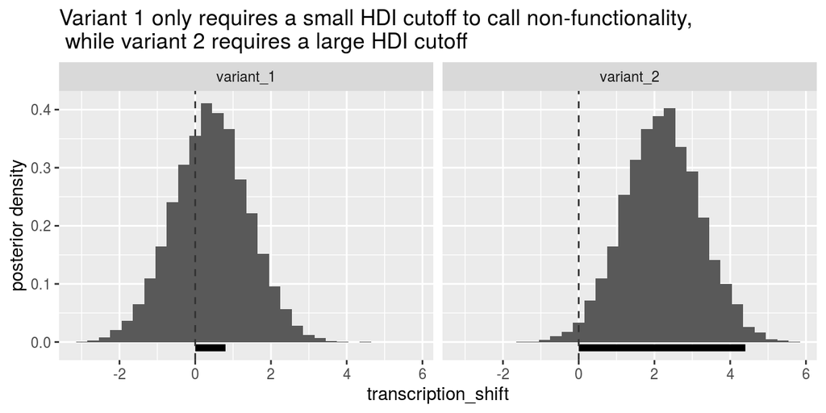

The fact that malacoda is fit with MCMC adds an additional complication to this procedure: some simulated variants with very strong effects will have all posterior samples of TS on one side of zero. This will lead to $p_i$ being exactly 0 or exactly 1, which in turn produces an incomplete precision-recall curve. In order to mitigate this, for variants falling into this category we use a linear approximation based off the relationship between the absolute estimated effect size and atanh(minimal HDI). In the figure below, we use the black line trained on the orange dots, to approximate the HDI cutoff needed for the blue dots. It can be seen that the orange points are gently curving upward above the approximation, so the extrapolated HDI cutoffs will tend to be conservative.

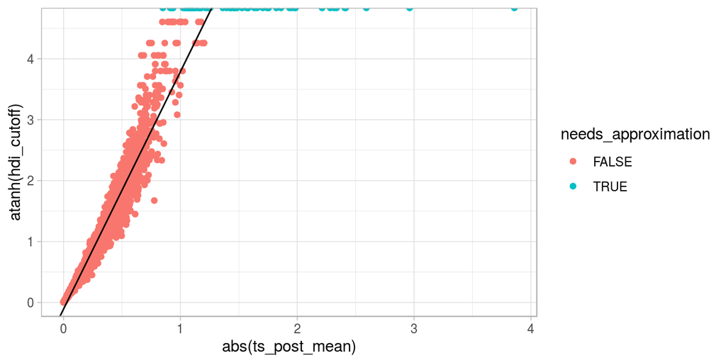

```r
sim_id = "zwnxvebu"

load(paste0('/mnt/bigData2/andrew/MPRA/sim_mpra/many_sims_malacoda/', sim_id, '/joined_df.RData'))

approx_lm = joined_df %>%
  filter(!(hdi_cutoff %in% c(0,1))) %>%
  lm(data = .,
     atanh(hdi_cutoff) ~ abs(ts_post_mean)) %>%
  summary

joined_df %>%
  mutate(needs_approximation = hdi_cutoff %in% c(0,1)) %>%
  ggplot(aes(abs(ts_post_mean),
             atanh(hdi_cutoff))) +
  geom_point(aes(color = needs_approximation)) +
  geom_abline(slope = approx_lm$coefficients[2,1],
              intercept = approx_lm$coefficients[1,1])+
  theme_light()
```

## 4.2 Run t-test on simulations

The code block below executes malacoda’s implementation of the activity t-test method to analyze the simulations and assess the performance in each.

```r
library(tidyverse)
library(malacoda)
library(pROC)

load('/mnt/bigData2/andrew/MPRA/sim_mpra/many_sims/sim_grid.RData')

get_t_sim_performance = function(sim_id){
  load(paste0('/mnt/bigData2/andrew/MPRA/sim_mpra/many_sims/', sim_id, '.RData'))

  fake_bcs = sample(x = c('A', 'C', 'G', 'T'),
                    size = nrow(unnest_legacy(current_sim))*16,
                    replace = TRUE) %>%
    matrix(nrow = nrow(unnest_legacy(current_sim))) %>%
    apply(MARGIN = 1, FUN = paste0, collapse = '')

  if (n_distinct(fake_bcs) < nrow(current_sim)){
    while (n_distinct(fake_bcs) < nrow(current_sim)) {
      fake_bcs = sample(x = c('A', 'C', 'G', 'T'),
                        size = nrow(current_sim)*16,
                        replace = TRUE) %>%
        matrix(nrow = nrow(current_sim)) %>%
        apply(MARGIN = 1, FUN = paste0, collapse = '')
    }
  }

  # Format simulated mpra data
  md = current_sim %>%
    unnest_legacy() %>%
    mutate(barcode = fake_bcs) %>%
    select(variant_id, allele, barcode, matches('[DR]NA', ignore.case = FALSE))

  sim_sd = get_sample_depths(md)

  wr = get_well_represented(md,
                            sample_depths = sim_sd,
                            rep_cutoff = .15,
                            plot_rep_cutoff = FALSE,
                            verbose = FALSE)

  precomputed_check = file.exists(paste0('/mnt/bigData2/andrew/MPRA/sim_mpra/many_sims_t/', sim_id, '_test_df.RData'))

  if (precomputed_check){
    load(paste0('/mnt/bigData2/andrew/MPRA/sim_mpra/many_sims_t/', sim_id, '_test_df.RData'))
  } else{

    act_df = compute_activities(md,
                                rep_cutoff = .15,
                                plot_rep_cutoff = FALSE)

    test_df = run_activity_tests(act_df,
                                 plot_p_hist = FALSE)

    save(test_df,
         file = paste0('/mnt/bigData2/andrew/MPRA/sim_mpra/many_sims_t/', sim_id, '_test_df.RData'))
  }


  if (any(current_sim$truly_functional)){
    perf_input = test_df %>%
      left_join(current_sim, by = 'variant_id') %>%
      mutate(fdr_hit = q_value < .05) %>%
      ungroup

      perf_df = perf_input %>%
      summarise(auc = auc(roc(predictor = .data$p.value,
                              response = .data$truly_functional,
                              quiet = TRUE)),
                pr = list(pROC::coords(roc(predictor = .data$p.value,
                              response = .data$truly_functional,
                              quiet = TRUE),
                            ret = c('recall', 'precision'),
                            transpose = FALSE)),
                mean_nzc = cor(ts_estimate[truly_functional], #mean non-zero correlation
                               effect_size[truly_functional]),
                mean_saz = sd(ts_estimate[!truly_functional]),
                typical_table = list(table(truly_functional,
                                           fdr_hit))) # mean spread at zero

      # Compute AUPR using the trapezoidal rule
      pr_mat = perf_df$pr[[1]] %>% .[nrow(.):1,] %>% .[!duplicated(.$recall),]
      nrow_pr = nrow(pr_mat)
      drecall = pr_mat[2:nrow_pr,1] - pr_mat[1:(nrow_pr - 1),1]
      avg_precision = (pr_mat[2:nrow_pr, 2] + pr_mat[1:(nrow_pr - 1), 2]) / 2
      avg_precision[1] = pr_mat[2,2] # the first precision value is returned as NaN -- set to next value
      daupr = drecall * avg_precision
      aupr = sum(daupr)

      perf_df$pr = NULL
      perf_df$aupr = aupr
  } else {
    perf_df =
      test_df %>%
      left_join(current_sim, by = 'variant_id') %>%
      mutate(fdr_hit = q_value < .05) %>%
      ungroup %>%
      summarise(auc = NA,
                mean_nzc = NA,
                mean_saz = sd(ts_estimate[!truly_functional]),
                typical_table = list(table(truly_functional,
                                           fdr_hit))) # mean spread at zero
  }

  save(perf_df,
       file = paste0('/mnt/bigData2/andrew/MPRA/sim_mpra/many_sims_t/', sim_id, '_perf_df.RData'))

  return(perf_df)
}

t_perf = suppressWarnings(sim_grid %>%
                             mutate(t_perf_call = parallel::mclapply(sim_id,
                                                                     get_t_sim_performance,
                                                                     mc.cores = 20,
                                                                     mc.preschedule = FALSE)) %>%
                             unnest_legacy() %>%
                             arrange(p_func, n_variants, n_bpa))

save(t_perf,
     file = '/mnt/bigData2/andrew/MPRA/sim_mpra/t_performance.RData')
```

## 4.3 Run mpralm on simulations

The code block below executes mpralm on the simulation grid defined above. The mpralm requires summing across RNA samples to ensure that there are the same number of DNA and RNA samples.

```r
library(tidyverse)
library(mpra)

mpralm_sim = function(sim_id){
  load(paste0('/mnt/bigData2/andrew/MPRA/sim_mpra/many_sims/', sim_id, '.RData'))

  mpra_data = current_sim %>% unnest()

  dna = mpra_data %>%
    select(variant_id, allele, matches('DNA')) %>%
  group_by(variant_id, allele) %>%
  summarise_at(paste0('DNA_', 1:3), sum) %>%
  ungroup %>% gather(sample_id, counts, matches('DNA')) %>%
  unite( col = 'allele_sample', allele, sample_id, sep = '_') %>%
  spread(allele_sample, counts) %>%
  column_to_rownames(var = 'variant_id') %>%
  as.matrix

rna = mpra_data %>%
    select(variant_id, allele, matches('RNA')) %>%
  group_by(variant_id, allele) %>%
  summarise_at(paste0('RNA_', 1:6), sum) %>%
  ungroup %>%
  gather(sample_id, counts, matches('RNA')) %>%
  mutate(sample_group = as.numeric(str_extract(sample_id, '[0-9]')) %% 3) %>%
  group_by(variant_id, allele, sample_group) %>%
  summarise(counts = sum(counts)) %>%
  unite( col = 'allele_sample', allele, sample_group, sep = '_') %>%
  spread(allele_sample, counts) %>%
  column_to_rownames(var = 'variant_id') %>%
  as.matrix %>%
  .[,1:6]


  element_ids = rownames(dna)
  colnames(rna) = colnames(dna)

  sim_mpra_set = MPRASet(DNA = dna,
                         RNA = rna,
                         eid = element_ids,
                         barcode = NULL,
                         eseq = NULL)

  design = data.frame(intcpt = 1,
                      alt_allele = grepl('alt', colnames(sim_mpra_set)))
  block_vector = rep(1:3, times = 2)

  mpralm_allele_fit <- mpralm(object = sim_mpra_set,
                              design = design,
                              aggregate = "none",
                              normalize = TRUE,
                              block = block_vector,
                              model_type = "indep_groups",
                              plot = TRUE)
  save(mpralm_allele_fit,
       file = paste0('/mnt/bigData2/andrew/MPRA/sim_mpra/many_sims_mpralm/', sim_id, '.RData'))

  return(':)')
}

load('/mnt/bigData2/andrew/MPRA/sim_mpra/many_sims/sim_grid.RData')

sim_grid %>%
  mutate(mpralm_res = parallel::mclapply(sim_id,
                                         mpralm_sim,
                                         mc.cores = 16,
                                         mc.preschedule = FALSE))
```

This code code block evaluates the performance of mpralm on the simulations.

```r
library(magrittr)
library(pROC)
eval_mpralm_fit = function(sim_id){
  load(paste0('/mnt/bigData2/andrew/MPRA/sim_mpra/many_sims/', sim_id, '.RData'))
  load(paste0('/mnt/bigData2/andrew/MPRA/sim_mpra/many_sims_mpralm/', sim_id, '.RData'))

  p_df = mpralm_allele_fit$p.value %>%
    as.data.frame() %>%
    rownames_to_column('variant_id') %>%
    as_tibble %>%
    mutate(q_value = p.adjust(alt_allele, method = 'fdr')) %>%
    left_join(current_sim %>% select(-variant_data),
              by = 'variant_id') %>%
    dplyr::rename(intcpt_p = intcpt, alt_allele_p = alt_allele, alt_allele_q = q_value)

  top_table = mpralm_allele_fit %>% topTable(number = nrow(p_df)) %>%
    rownames_to_column(var = 'variant_id') %>%
    as_tibble %>%
    select(-(4:7))

  if (all(!current_sim$truly_functional)){
    res_df = p_df %>% left_join(top_table, by = 'variant_id')

    spread_at_0 = res_df %>%
      mutate(rescaled = log(2**alt_allele)) %>%
      filter(!truly_functional) %>%
      pull(rescaled) %>%
      sd

    typical_table = res_df %>%
      mutate(fdr_call = alt_allele_q < .05) %>%
      select(fdr_call, truly_functional) %>%
      table

    out_df = tibble(spread_at_0 = spread_at_0,
                    auc = NA,
                    nonzero_cor = NA,
                    aupr = NA,
                    `5%FDR_calls` = list(typical_table))
    return(out_df)
  }

  res_df = p_df %>% left_join(top_table, by = 'variant_id')

  roc_obj = roc(predictor = res_df$alt_allele_p,
        response = res_df$truly_functional, quiet = TRUE)

  auc_val = auc(roc_obj)

  pr_obj = pROC::coords(roc_obj,
                  ret = c('recall', 'precision'),
                  transpose = FALSE)

  # Compute AUPR using the trapezoidal rule
  pr_mat = pr_obj %>% .[nrow(.):1,] %>% .[!duplicated(.$recall),]
  nrow_pr = nrow(pr_mat)
  drecall = pr_mat[2:nrow_pr,1] - pr_mat[1:(nrow_pr - 1),1]
  avg_precision = (pr_mat[2:nrow_pr, 2] + pr_mat[1:(nrow_pr - 1), 2]) / 2
  avg_precision[1] = pr_mat[2,2] # the first precision value is returned as NaN -- set to next value
  daupr = drecall * avg_precision
  aupr = sum(daupr)


  save(roc_obj, auc_val, aupr,
       file = paste0('/mnt/bigData2/andrew/MPRA/sim_mpra/many_sims_mpralm/', sim_id, '_roc.RData'))

  nonzero_cor = res_df %>%
    filter(truly_functional) %$%
    cor(alt_allele, effect_size)

  spread_at_0 = res_df %>%
    mutate(rescaled = log(2**alt_allele)) %>%
    filter(!truly_functional) %>%
    pull(rescaled) %>%
    sd

  save(nonzero_cor, spread_at_0,
       file = paste0('/mnt/bigData2/andrew/MPRA/sim_mpra/many_sims_mpralm/', sim_id, '_es.RData'))

  typical_table = res_df %>%
    mutate(fdr_call = alt_allele_q < .05) %>%
    select(fdr_call, truly_functional) %>%
    table

  out_df = tibble(spread_at_0 = spread_at_0,
                  auc = auc_val,
                  nonzero_cor = nonzero_cor,
                  aupr = aupr,
                  `5%FDR_calls` = list(typical_table))
  return(out_df)
}
```

```r
mpralm_sim_performance = sim_grid %>%
  mutate(eval_metrics = mclapply(sim_id, eval_mpralm_fit, mc.cores = 18)) %>%
  unnest_legacy

save(mpralm_sim_performance,
     file = '/mnt/bigData2/andrew/MPRA/sim_mpra/mpralm_sim_performance.RData')
```

## 4.4 Run MPRAscore on simulations

```r
library(tidyverse)
library(magrittr)

mprascore_sim = function(sim_id){
  load(paste0('/mnt/bigData2/andrew/MPRA/sim_mpra/many_sims/', sim_id, '.RData'))

    fake_bcs = sample(x = c('A', 'C', 'G', 'T'),
                    size = nrow(unnest(current_sim))*18,
                    replace = TRUE) %>%
    matrix(nrow = nrow(unnest(current_sim))) %>%
    apply(MARGIN = 1, FUN = paste0, collapse = '')

  current_sim %<>%
    unnest_legacy %>%
    mutate(Barcode = fake_bcs)

  # make the "oligo" file

  og_table = current_sim %>%
    mutate(Oligo = paste(variant_id, allele, sep = '_'),
           Strand = '+',
           baseOffset = 0) %>%
    select(-matches('[DR]NA'), -Barcode, -bc_id, -failed, -variant_id1, -truly_functional, -effect_size) %>%
    unique %>%
    group_by(variant_id) %>%
    mutate(allele_letter = base::sample(c('A', 'C', 'G', 'T'), size  = 2, replace = FALSE)) %>%
    ungroup

  spread_table = og_table %>%
    select(variant_id, allele, allele_letter) %>%
    spread(allele, allele_letter)

  oligo_output = current_sim %>%
    mutate(Oligo = paste(variant_id, allele, sep = '_')) %>%
    left_join(spread_table, by = 'variant_id') %>%
    dplyr::rename(Ref = ref, Alt = alt) %>%
    mutate(Allele_in_oligo = case_when(allele == 'ref' ~ Ref,
                                       TRUE ~ Alt)) %>%
    mutate(Strand = '+',
           baseOffset = 0) %>%
    select(Oligo, RSID = variant_id, Ref, Alt, Allele_in_oligo, Strand, baseOffset) %>%
    unique

 oligo_out_path = paste0('/mnt/bigData2/andrew/MPRA/sim_mpra/many_sims_mprascore/', sim_id, '_oligos.txt')
  write_tsv(oligo_output,
            path = oligo_out_path)

  # make the "bc counts" file

  bc_counts = current_sim %>%
    mutate(Oligo = paste(variant_id, allele, sep = '_')) %>%
    select(BC = Barcode, Oligo, matches('[DR]NA', ignore.case = FALSE))

  bc_out_path = paste0('/mnt/bigData2/andrew/MPRA/sim_mpra/many_sims_mprascore/', sim_id, '_bc_counts.txt')
  write_tsv(bc_counts,
            path = bc_out_path)

  # make output path & command

  out_path = paste0('/mnt/bigData2/andrew/MPRA/sim_mpra/many_sims_mprascore/', sim_id, '_out.txt')

  mprascore_cmd = paste0('mprascore ',
                         oligo_out_path, ' ',
                         bc_out_path, ' ',
                         '-RNAcols:', paste0('RNA_', 1:6, collapse = ','), ' ',
                         '-DNAcols:DNA_1,DNA_2,DNA_3 ',
                         out_path, ' ',
                         '-p:1000')

  # run command

  system(mprascore_cmd)

  return('donesk')
}

load('/mnt/bigData2/andrew/MPRA/sim_mpra/many_sims/sim_grid.RData')

sim_grid %>%
  mutate(ms_res = parallel::mclapply(sim_id,
                                     mprascore_sim,
                                     mc.cores = 16,
                                     mc.preschedule = FALSE))
```

The code block below evaluates the performance of MPRAscore on each simulation.

```r
library(pROC)

assess_ms_output = function(sim_id){
  id_outputs = read_tsv(paste0('/mnt/bigData2/andrew/MPRA/sim_mpra/many_sims_mprascore/', sim_id, '_out.txt'))
  load(paste0('/mnt/bigData2/andrew/MPRA/sim_mpra/many_sims/', sim_id, '.RData'))

  current_sim %<>% left_join(id_outputs, by = c('variant_id' = 'RSID'))

  if (any(current_sim$truly_functional)){
    roc_obj = roc(response = current_sim$truly_functional,
                  predictor = current_sim$p_perm)

    auc_val = auc(roc_obj)
    pr_obj = pROC::coords(roc_obj,
                    ret = c('recall', 'precision'),
                    transpose = FALSE)

    # Compute AUPR using the trapezoidal rule
    pr_mat = pr_obj %>% .[nrow(.):1,] %>% .[!duplicated(.$recall),]
    nrow_pr = nrow(pr_mat)
    drecall = pr_mat[2:nrow_pr,1] - pr_mat[1:(nrow_pr - 1),1]
    avg_precision = (pr_mat[2:nrow_pr, 2] + pr_mat[1:(nrow_pr - 1), 2]) / 2
    avg_precision[1] = pr_mat[2,2] # the first precision value is returned as NaN -- set to next value
    daupr = drecall * avg_precision
    aupr = sum(daupr)

  } else{
    auc_val = NA
    aupr = NA
  }

  typical_table = current_sim %>%
    mutate(fdr_hit = q_perm < .05) %>%
    select(truly_functional, fdr_hit) %>%
    table

  nonzero_cor = current_sim %>%
    filter(truly_functional) %$%
    cor(effect_size, score)

  spread_at_zero = current_sim %>%
    filter(!truly_functional) %>%
    pull(score) %>%
    sd

  res_df = tibble(auc = auc_val,
                  aupr = aupr,
                  typical_table = list(typical_table),
                  spread_at_zero = spread_at_zero,
                  nonzero_cor = nonzero_cor)
}

load('/mnt/bigData2/andrew/MPRA/sim_mpra/many_sims/sim_grid.RData')

ms_performance = sim_grid %>%
  mutate(perf_table = pbmcapply::pbmclapply(sim_id,
                                            assess_ms_output,
                                            mc.cores = 16))

save(ms_performance,
     file = '~/dev_malacoda/outputs/mprascore/ms_performance.RData')
```

## 4.5 Run QuASAR-MPRA on simulations

```r
library(QuASAR)
library(tidyverse)
library(pROC)
library(magrittr)
load('/mnt/bigData2/andrew/MPRA/sim_mpra/many_sims/sim_grid.RData')

fit_and_assess_qm = function(sim_id){
  load(paste0('/mnt/bigData2/andrew/MPRA/sim_mpra/many_sims/', sim_id, '.RData'))

  unnested = current_sim %>%
    select(-variant_id) %>%
    unnest(c(variant_data))

  qm_input = unnested %>%
    select(variant_id, allele, matches('[DR]NA', ignore.case = FALSE)) %>%
    gather(sample_id, count, -(1:2)) %>%
    group_by(variant_id) %>%
    summarise(ref_rna = sum(count[grepl('RNA', sample_id) & allele == 'ref']),
              alt_rna = sum(count[grepl('RNA', sample_id) & allele != 'ref']),
              dna_prop = sum(count[grepl('DNA', sample_id) & allele == 'ref']) / sum(count[grepl('DNA', sample_id)]))

  qm_sim = fitQuasarMpra(qm_input$ref_rna,
                         qm_input$alt_rna,
                         qm_input$dna_prop) %>%
    bind_cols(qm_input %>% select(variant_id))

  save(qm_sim,
       file = paste0('/mnt/bigData2/andrew/MPRA/sim_mpra/many_sims_qm/', sim_id, '.RData'))

  res_df = current_sim %>% left_join(qm_sim, by = 'variant_id') %>%
    mutate(betas.beta.binom = -betas.beta.binom) # QM uses an unintuitive directionality

  if (any(current_sim$truly_functional)){
    roc_obj = roc(predictor = res_df$pval3,
                  response = res_df$truly_functional)

    auc_val = auc(roc_obj)

    pr_obj = pROC::coords(roc_obj,
                          ret = c('recall', 'precision'),
                          transpose = FALSE)

    # Compute AUPR using the trapezoidal rule
    pr_mat = pr_obj %>% .[nrow(.):1,] %>% .[!duplicated(.$recall),]
    nrow_pr = nrow(pr_mat)
    drecall = pr_mat[2:nrow_pr,1] - pr_mat[1:(nrow_pr - 1),1]
    avg_precision = (pr_mat[2:nrow_pr, 2] + pr_mat[1:(nrow_pr - 1), 2]) / 2
    avg_precision[1] = pr_mat[2,2] # the first precision value is returned as NaN -- set to next value
    daupr = drecall * avg_precision
    aupr = sum(daupr)

    save(roc_obj, aupr, auc_val,
         file = paste0('/mnt/bigData2/andrew/MPRA/sim_mpra/many_sims_qm/', sim_id, '_roc.RData'))

    nonzero_cor = res_df %>%
      filter(truly_functional) %$%
      cor(betas.beta.binom, effect_size)

    spread_at_0 = res_df %>%
      filter(!truly_functional) %>%
      pull(betas.beta.binom) %>%
      sd

    save(nonzero_cor, spread_at_0,
         file = paste0('/mnt/bigData2/andrew/MPRA/sim_mpra/many_sims_qm/', sim_id, '_es.RData'))

    perf_df = tibble(spread_at_0 = spread_at_0,
                     auc = auc_val,
                     nonzero_cor = nonzero_cor,
                     aupr = aupr)

    save(perf_df,
         file = paste0('/mnt/bigData2/andrew/MPRA/sim_mpra/many_sims_qm/', sim_id, '_perf_df.RData'))
  } else {

    spread_at_0 = res_df %>%
      filter(!truly_functional) %>%
      pull(betas.beta.binom) %>%
      sd

    perf_df = tibble(spread_at_0 = spread_at_0,
                     auc = as.numeric(NA),
                     nonzero_cor = as.numeric(NA),
                     aupr = as.numeric(NA))
    save(perf_df,
         file = paste0('/mnt/bigData2/andrew/MPRA/sim_mpra/many_sims_qm/', sim_id, '_perf_df.RData'))
  }

  return('donesk :)')

}

cl = parallel::makeCluster(20, type = "FORK")
pbapply::pblapply(sim_grid$sim_id,
                  fit_and_assess_qm,
                  cl = cl)

get_qm_perf = function(sim_id){
  load(paste0('/mnt/bigData2/andrew/MPRA/sim_mpra/many_sims_qm/', sim_id, '_perf_df.RData'))
  return(perf_df)
}

qm_perf = sim_grid %>%
  mutate(perf_dfs = map(sim_id, get_qm_perf)) %>%
  unnest_legacy() %>%
  group_by(p_func, n_variants, n_bpa) %>%
  summarise(med_saz = median(`spread_at_0`),
            med_nzc = median(nonzero_cor),
            med_auc = median(auc),
            med_aupr = median(aupr)) %>%
  ungroup %>%
  gather(metric, value, matches('med_')) %>%
  mutate(method = 'QuASAR-MPRA')

save(qm_perf,
     file = '/home/andrew/dev_malacoda/outputs/qm_perf.RData')
```